# INFSCI 2595 Final Project

Part 3C, Classification - Prediction

Zhenyu Li

2022-04-22

```r
library(tidyverse)
theme_set(theme_linedraw())
library(rstanarm)
options(mc.cores = parallel::detectCores())
library(bayesplot)
source("./scripts/utils.R")
```

```r
df <- readr::read_csv("./data/final_project_train.csv", col_names = TRUE)
df_prep_cl <- df %>%
  mutate_if(is.character,as.factor) %>%
  select(-c(rowid,response)) %>%
  mutate(
    across(starts_with("x"), scale)
  )
my_inputs <- setdiff(names(df_prep_cl),"outcome")
```

In this section, I will visualize how the generalized linear models predict the event probability of `outcome` based on some selected inputs.

## Preparation

### Model Selection

**Select two Bayesian models from 3B for prediction and visualization.**

- Since all three Bayesian models have similar performance, I will just choose the two with more features so that there are more potential ways to visualize.
- One with all inputs in linear additive relationship `mod_3B2_3A3`.
- One with some interactions of the inputs `mod_3B3_3Ac2`.

```r
mod_3A3 <- readr::read_rds("models/mod_3A3")
mod_3B2_3A3 <- readr::read_rds("models/mod_3B2_3A3")
mod_3Ac2 <- readr::read_rds("models/mod_3Ac2")
mod_3B3_3Ac2 <- readr::read_rds("models/mod_3B3_3Ac2")
```

### Input Selection

**Select inputs to visualize, based on model coefficient significance.**

**First model, plot significant coefficients.**

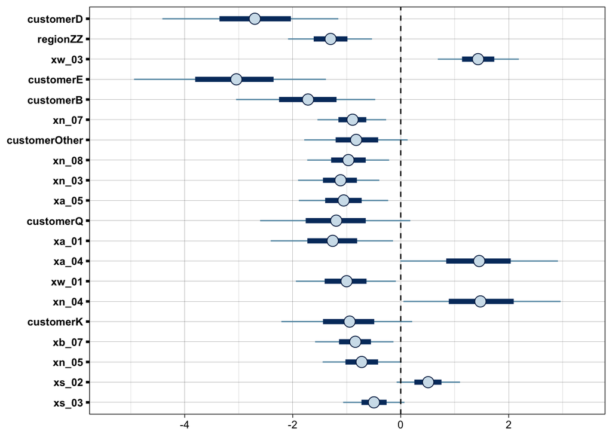

```r
mod_3B2_3A3 %>% as_tibble() %>%
  select(all_of(
    mod_3A3 %>% pull_lm_coefs_signif(top_n = 20) %>% select(coef) %>% unlist(use.names=F)
  )) %>%
  # mcmc_areas_ridges(prob=0.6, prob_outer = 0.9) +
  mcmc_intervals() +
  geom_vline(xintercept = 0,linetype="dashed")
```

**Second model, plot significant coefficients.**

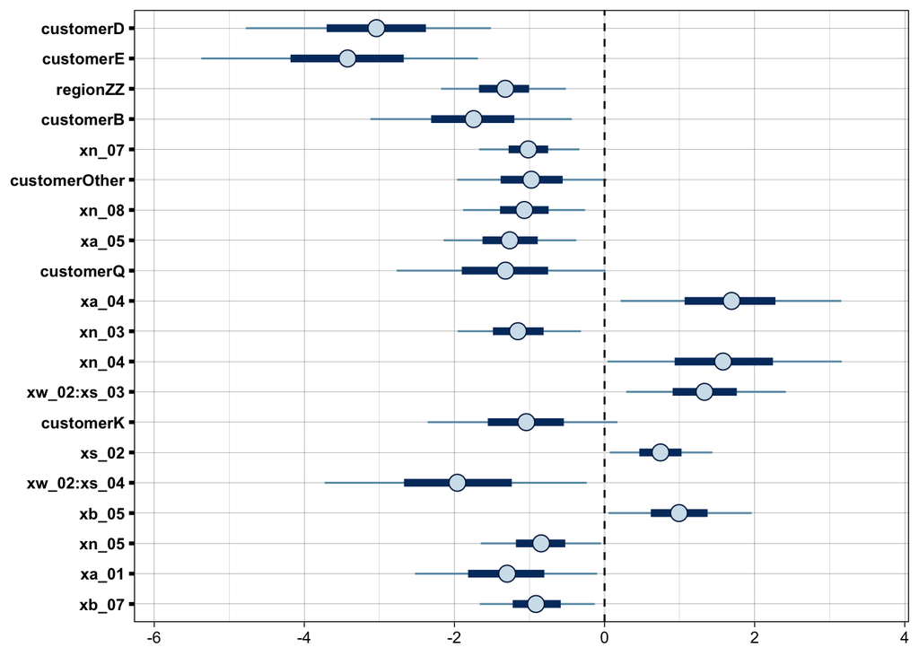

```r
mod_3B3_3Ac2 %>% as_tibble() %>%
  select(all_of(
    mod_3Ac2 %>% pull_lm_coefs_signif(top_n = 20) %>% select(coef) %>% unlist(use.names=F)
  )) %>%
  # mcmc_areas_ridges(prob=0.6, prob_outer = 0.9) +
  mcmc_intervals() +
  geom_vline(xintercept = 0,linetype="dashed")
```

**Choose predictors to use based on important features of both models.**

## Predictions

### Set 1: xw_03, xn_07

This set of inputs are associated with the top 2 ranked coefficients.

```r
viz_grid <- make_test_input_grid(my_inputs, df_prep_cl, c("xw_03", "xn_07"))
```

**First model**

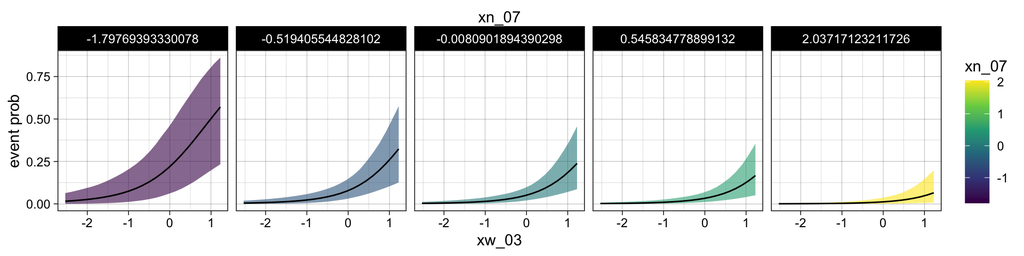

```r
make_post_pred_cl(mod_3B2_3A3, viz_grid) %>% ggplot(aes(x=xw_03, fill=xn_07)) +
  geom_ribbon(aes(ymin = trend_lwr, ymax = trend_upr), alpha=0.6) +
  geom_line(aes(y = trend_avg), size=0.5) +
  facet_grid(~xn_07, scales="free_y") +
  scale_x_continuous(sec.axis = sec_axis(~ ., name = "xn_07", breaks = NULL, labels = NULL)) +
  scale_fill_viridis_c() + ylab("event prob")
```

- The predicted mean event probability increases with the input `xw_03`. (each facet)
- The predicted mean event probability decreases with the input `xn_07`. (across facets)
- There is higher uncertainty in model behavior
  - when the `xw_03` is high (each facet, right), or
  - when the `xn_07` is low (across facets, left)

**Second model**

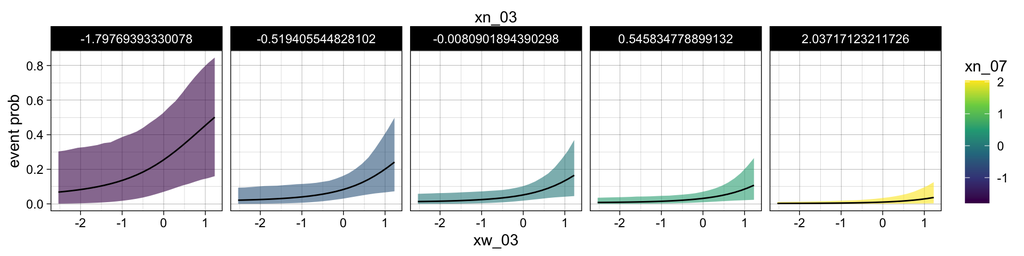

```r
make_post_pred_cl(mod_3B3_3Ac2, viz_grid) %>% ggplot(aes(x=xw_03, fill=xn_07)) +
  geom_ribbon(aes(ymin = trend_lwr, ymax = trend_upr), alpha=0.6) +
  geom_line(aes(y = trend_avg), size=0.5) +
  facet_grid(~xn_07, scales="free_y") +
  scale_x_continuous(sec.axis = sec_axis(~ ., name = "xn_03", breaks = NULL, labels = NULL)) +
  scale_fill_viridis_c() + ylab("event prob")
```

### Set 2: xw_03, xn_07, xn_08

This set of inputs are associated with the top 3 most important coefficients.

```r
viz_grid <- make_test_input_grid(my_inputs, df_prep_cl, c("xw_03", "xn_07", "xn_08"))
```

**First model**

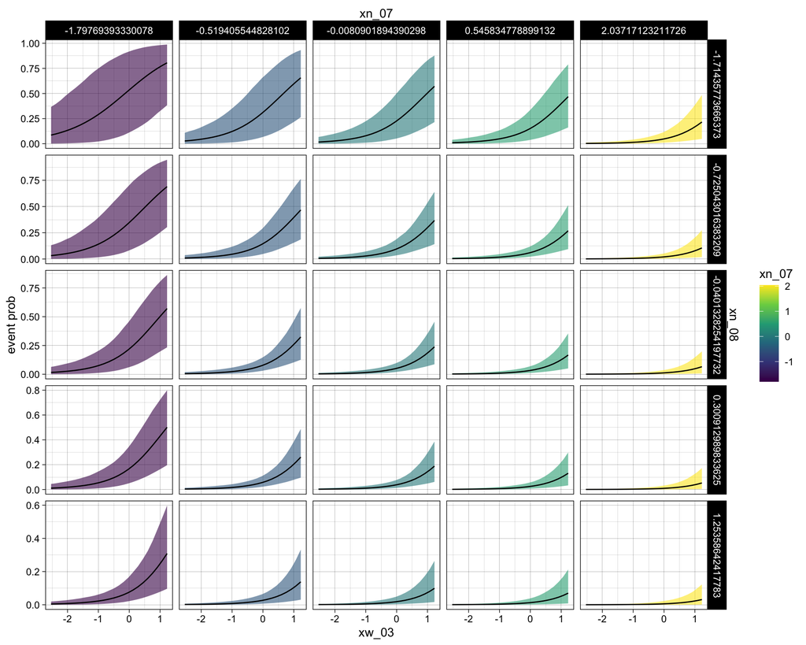

```r
make_post_pred_cl(mod_3B2_3A3, viz_grid) %>% ggplot(aes(x=xw_03, fill=xn_07)) +
  geom_ribbon(aes(ymin = trend_lwr, ymax = trend_upr), alpha=0.6) +
  geom_line(aes(y = trend_avg), size=0.5) +
  facet_grid(xn_08 ~ xn_07, scales="free_y") +
  scale_x_continuous(sec.axis = sec_axis(~ ., name = "xn_07", breaks = NULL, labels = NULL)) +
  scale_y_continuous(sec.axis = sec_axis(~ ., name = "xn_08", breaks = NULL, labels = NULL)) +
  scale_fill_viridis_c() + ylab("event prob")
```

**Second model**

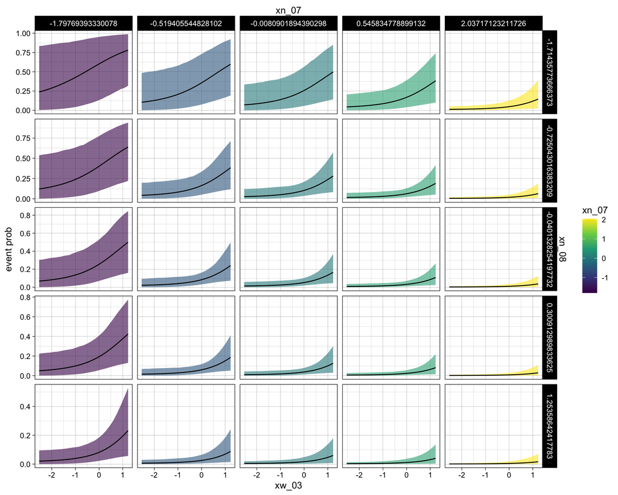

```r
make_post_pred_cl(mod_3B3_3Ac2, viz_grid) %>% ggplot(aes(x=xw_03, fill=xn_07)) +
  geom_ribbon(aes(ymin = trend_lwr, ymax = trend_upr), alpha=0.6) +
  geom_line(aes(y = trend_avg), size=0.5) +
  facet_grid(xn_08 ~ xn_07, scales="free_y") +
  scale_x_continuous(sec.axis = sec_axis(~ ., name = "xn_07", breaks = NULL, labels = NULL)) +
  scale_y_continuous(sec.axis = sec_axis(~ ., name = "xn_08", breaks = NULL, labels = NULL)) +
  scale_fill_viridis_c() + ylab("event prob")
```

- Same trend as with the first model. In comparison, this model has more uncertainty with low values, but more precise when inputs have higher values.

### Set 3: xw_03, customer

This set expands the top ranked continuous input with the customer categorical input.

```r
viz_grid <- make_test_input_grid(my_inputs, df_prep_cl, c("xw_03"), "customer")
```

**First model**

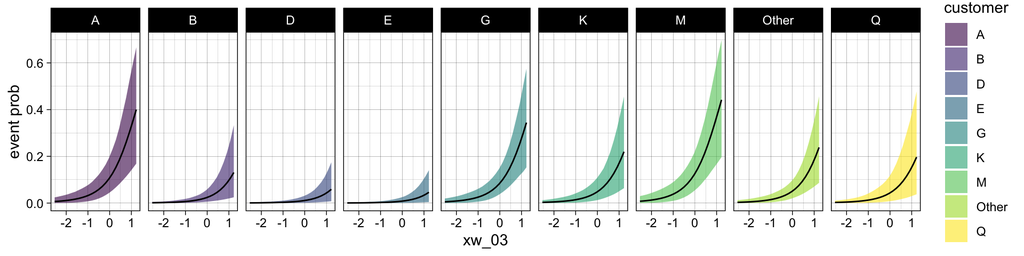

```r
make_post_pred_cl(mod_3B2_3A3, viz_grid) %>% ggplot(aes(x=xw_03, fill=customer)) +
  geom_ribbon(aes(ymin = trend_lwr, ymax = trend_upr), alpha=0.6) +
  geom_line(aes(y = trend_avg), size=0.5) +
  facet_grid(~customer, scales="free_y") +
  scale_fill_viridis_d() + ylab("event prob")
```

- This plot aims to look at how the top ranked continuous input can predict different customers.
  - It is clear that `customer` category affects the ability for `xw_03` to predict. (horizontal facets)
  - It is especially uncertain to predict for customers A and M.

**Second model**

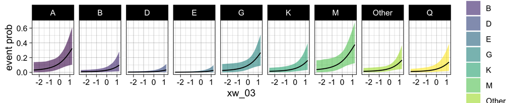

```r
make_post_pred_cl(mod_3B3_3Ac2, viz_grid) %>% ggplot(aes(x=xw_03, fill=customer)) +
  geom_ribbon(aes(ymin = trend_lwr, ymax = trend_upr), alpha=0.6) +
  geom_line(aes(y = trend_avg), size=0.5) +
  facet_grid(~customer, scales="free_y") +
  scale_fill_viridis_d() + ylab("event prob")
```

- The overall event probability trends are consistent across the two models.
- The uncertainty to predict the aforementioned customers is higher, but slightly lower for the rest customers.

### Set 4: xw_02, xs_03

This set aims to examine how the interactions affects the predictions, thus uses the inputs associated with the top ranked coefficient with interactions.

```r
viz_grid <- make_test_input_grid(my_inputs, df_prep_cl, c("xw_02","xs_03"))
```

**First model**

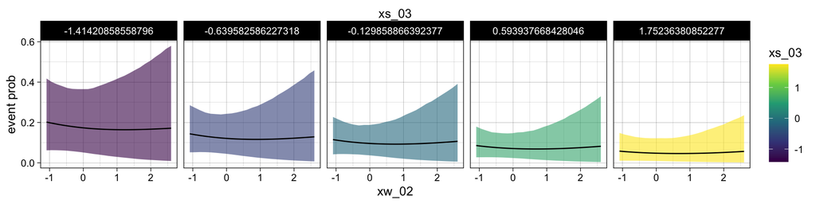

```r
make_post_pred_cl(mod_3B2_3A3, viz_grid) %>% ggplot(aes(x=xw_02, fill=xs_03)) +
  geom_ribbon(aes(ymin = trend_lwr, ymax = trend_upr), alpha=0.6) +
  geom_line(aes(y = trend_avg), size=0.5) +
  facet_grid(~xs_03, scales="free_y") +
  scale_x_continuous(sec.axis = sec_axis(~ ., name = "xs_03", breaks = NULL, labels = NULL)) +
  scale_fill_viridis_c() + ylab("event prob")
```

- The first model does not have interaction features, thus the overall trend does not change w.r.t. the two inputs.

**Second model**

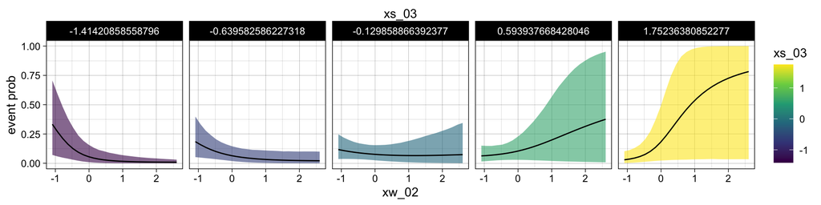

```r
make_post_pred_cl(mod_3B3_3Ac2, viz_grid) %>% ggplot(aes(x=xw_02, fill=xs_03)) +
  geom_ribbon(aes(ymin = trend_lwr, ymax = trend_upr), alpha=0.6) +
  geom_line(aes(y = trend_avg), size=0.5) +
  facet_grid(~xs_03, scales="free_y") +
  scale_x_continuous(sec.axis = sec_axis(~ ., name = "xs_03", breaks = NULL, labels = NULL)) +
  scale_fill_viridis_c() + ylab("event prob")
```

- With the second model, we see the interaction does have some effects.
- The prediction of event probability by first term `xw_02` is affected by the value of the second term `xs_03`.
  - When `xs_03` is low (purple), and `xw_02` is low (left), there is higher uncertainty predicting slightly higher event probability.
  - When `xs_03` is high (yellow), there is tremendous uncertainty for predicting event probability once `xw_02` value increases. But with low `xw_02` values the model predicts low event probability with more confidence.
  - When both `xs_03` is not extreme, model predicts low event probability with more confidence.

## Conclusions

- The overall predicted event probability trend is consistent across the two models compared.
- We see some features could affect the uncertainty in model prediction.
- It’s worth consider adding the interactions between categorical inputs and the continuous inputs. But because of the way I crafted models (arbitrary interactions) and filtered models (information criterion), these possibilities were ruled out due to added model complexity.
- I will consider using regularization to tune these complex models with interactions to find those interactive terms that make most sense.